# 14_compare_boxplots

## 14_compare_boxplots

#### Question

1. Five different populations were sampled, and the measurements were visualized as five [boxplots](https://en.wikipedia.org/wiki/Box_plot). (Note: typical boxplots indicate outliers with dots. For simplicity, these boxplots include all outliers in the whiskers.)

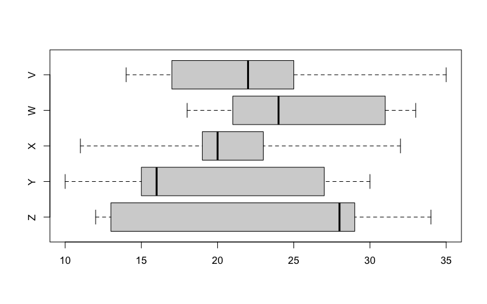

   1. Which sample contains the largest value?
   2. Which sample contains the smallest value?
   3. Which sample has the largest median?
   4. Which sample has the smallest median?
   5. Which sample has the largest IQR?
   6. Which sample has the smallest IQR?

#### Question

2. Five different populations were sampled, and the measurements were visualized as five [boxplots](https://en.wikipedia.org/wiki/Box_plot). (Note: typical boxplots indicate outliers with dots. For simplicity, these boxplots include all outliers in the whiskers.)

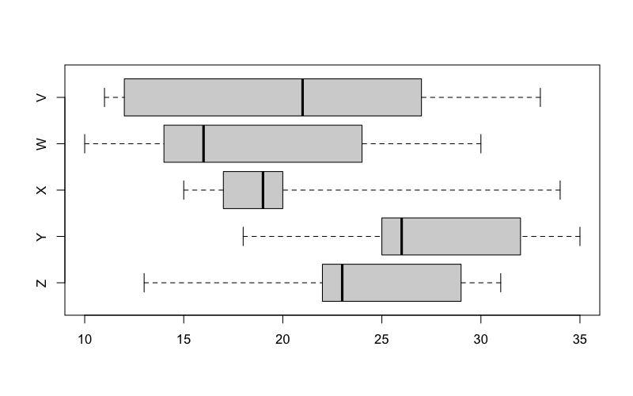

   1. Which sample contains the largest value?
   2. Which sample contains the smallest value?
   3. Which sample has the largest median?
   4. Which sample has the smallest median?
   5. Which sample has the largest IQR?
   6. Which sample has the smallest IQR?

#### Question

3. Five different populations were sampled, and the measurements were visualized as five [boxplots](https://en.wikipedia.org/wiki/Box_plot). (Note: typical boxplots indicate outliers with dots. For simplicity, these boxplots include all outliers in the whiskers.)

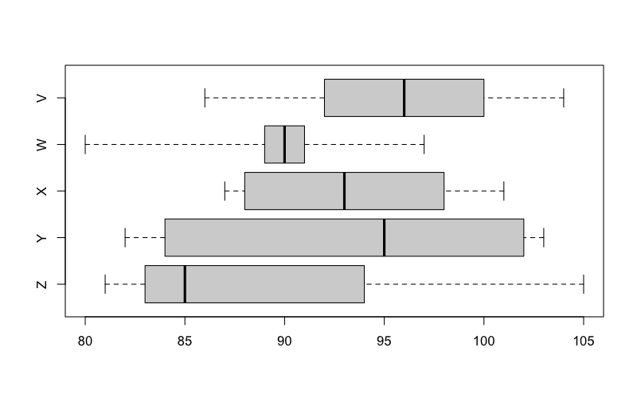

   1. Which sample contains the largest value?
   2. Which sample contains the smallest value?
   3. Which sample has the largest median?
   4. Which sample has the smallest median?
   5. Which sample has the largest IQR?
   6. Which sample has the smallest IQR?

#### Question

4. Five different populations were sampled, and the measurements were visualized as five [boxplots](https://en.wikipedia.org/wiki/Box_plot). (Note: typical boxplots indicate outliers with dots. For simplicity, these boxplots include all outliers in the whiskers.)

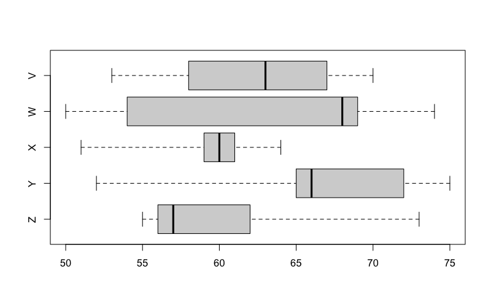

   1. Which sample contains the largest value?
   2. Which sample contains the smallest value?
   3. Which sample has the largest median?
   4. Which sample has the smallest median?
   5. Which sample has the largest IQR?
   6. Which sample has the smallest IQR?

#### Question

5. Five different populations were sampled, and the measurements were visualized as five [boxplots](https://en.wikipedia.org/wiki/Box_plot). (Note: typical boxplots indicate outliers with dots. For simplicity, these boxplots include all outliers in the whiskers.)

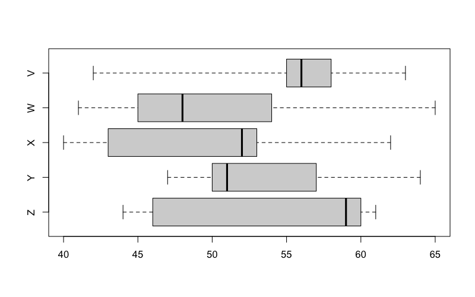

   1. Which sample contains the largest value?
   2. Which sample contains the smallest value?
   3. Which sample has the largest median?
   4. Which sample has the smallest median?
   5. Which sample has the largest IQR?
   6. Which sample has the smallest IQR?

#### Question

6. Five different populations were sampled, and the measurements were visualized as five [boxplots](https://en.wikipedia.org/wiki/Box_plot). (Note: typical boxplots indicate outliers with dots. For simplicity, these boxplots include all outliers in the whiskers.)

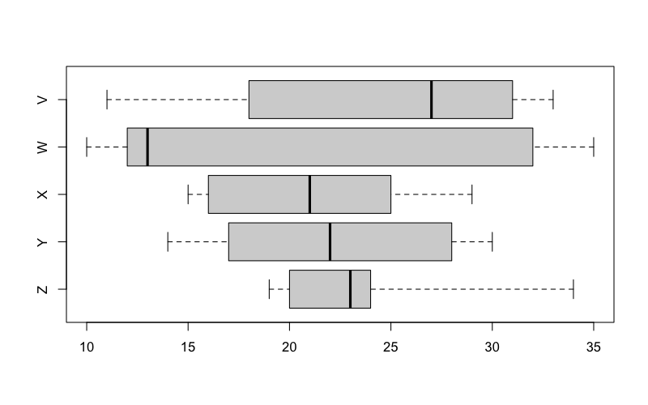

   1. Which sample contains the largest value?
   2. Which sample contains the smallest value?
   3. Which sample has the largest median?
   4. Which sample has the smallest median?
   5. Which sample has the largest IQR?
   6. Which sample has the smallest IQR?

#### Question

7. Five different populations were sampled, and the measurements were visualized as five [boxplots](https://en.wikipedia.org/wiki/Box_plot). (Note: typical boxplots indicate outliers with dots. For simplicity, these boxplots include all outliers in the whiskers.)

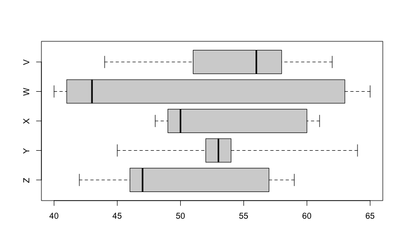

   1. Which sample contains the largest value?
   2. Which sample contains the smallest value?
   3. Which sample has the largest median?
   4. Which sample has the smallest median?
   5. Which sample has the largest IQR?
   6. Which sample has the smallest IQR?

#### Question

8. Five different populations were sampled, and the measurements were visualized as five [boxplots](https://en.wikipedia.org/wiki/Box_plot). (Note: typical boxplots indicate outliers with dots. For simplicity, these boxplots include all outliers in the whiskers.)

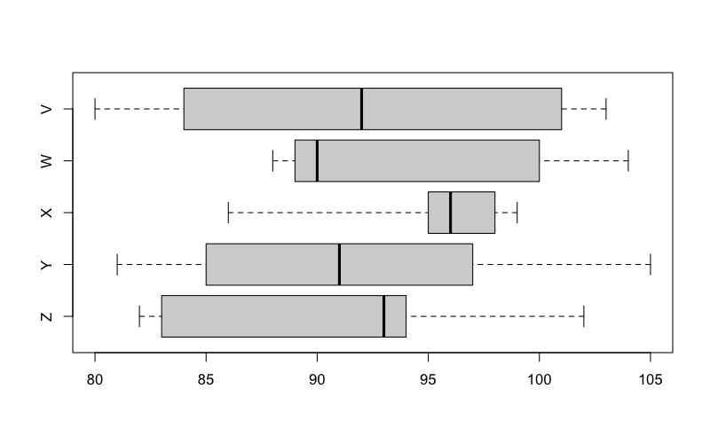

   1. Which sample contains the largest value?
   2. Which sample contains the smallest value?
   3. Which sample has the largest median?
   4. Which sample has the smallest median?
   5. Which sample has the largest IQR?
   6. Which sample has the smallest IQR?